# Module 6 worksheet

```r
library(ggplot2) #load ggplot
library(ggthemes) #load themes package for ggplot
theme_set(theme_tufte()) # a theme I like.

#set some options that I like
theme_update(plot.title = element_text(hjust = 0.5),
             axis.line.x = element_line(color="black", size = 1),
             axis.line.y = element_line(color="black", size = 1),
             text=element_text(size=20),
             axis.text=element_text(size=15)) #center all titles and and axis lines
```

# Exercise 6A

## Examining multicollinearity

This example uses data from the Maryland Biological Stream Survey, downloaded from: http://udel.edu/~mcdonald/statmultreg.html. We are interested in predicting the abundance of longnose dace using chemical and biological characteristics of a stream.

The dependent variable is the number of longnose dace, **longnosedace**, per 75-meter section of stream. The independent variables are the **acreage** drained by the stream; the dissolved oxygen, **do2**, in mg/liter; the maximum depth, **maxdepth**, in cm of the 75-meter segment of stream; nitrate concentration, **no3**, in mg/liter; sulfate concentration, **so4**, in mg/liter; water temperature, **temp**, on the sampling date in degrees C, and the stream conductivity, **conduct**, in uS/cm.

1. Create a linear model of longnosedace with all the covariates in the model.
2. load the `car` library and calculate the variance inflation factors using the function `vif`.

```r
dace.dat <- read.csv(file="../Data/longnosedace.csv")
full.mod <- lm(longnosedace ~ acreage + do2 + maxdepth + no3 + so4 + temp + conduct, data=dace.dat)

library(car)
vif(full.mod)
```

```
 acreage      do2 maxdepth      no3      so4     temp  conduct
1.104984 3.202636 1.161897 5.009860 1.023701 1.141963 8.384964
```

### This suggests that conductance is collinear with one or more of the other predictors. Removing conductance (below) fixes the issue with collinearity.

```r
full.mod <- lm(longnosedace ~ acreage + do2 + maxdepth + no3 + so4 + temp, data=dace.dat)

vif(full.mod)
```

```
 acreage      do2 maxdepth      no3      so4     temp
1.089705 1.223004 1.087399 1.113794 1.020370 1.129060
```

# Exercise 6B

## F-tests and adjusted $R^2$

Create two models of the longose dace, the full model and a model with just the predictors `acreage` and `maxdepth`. 1. Report the adjusted $R^2$ values for these models. Based on this criterion, which is the better model? 2. Now run an F-test with the `anova` function. What does the p-value tell you?

```r
mod2 <- lm(longnosedace ~ acreage + do2 + maxdepth + no3 + so4 + temp + conduct, data=dace.dat)
mod3 <- lm(longnosedace ~ acreage + maxdepth, data=dace.dat)

anova(mod2, mod3)
```

```
Analysis of Variance Table

Model 1: longnosedace ~ acreage + do2 + maxdepth + no3 + so4 + temp +
    conduct
Model 2: longnosedace ~ acreage + maxdepth
  Res.Df    RSS Df Sum of Sq      F  Pr(>F)
1     60 101139
2     65 124393 -5    -23255 2.7591 0.02615 *
---
Signif. codes:  0 ‘***’ 0.001 ‘**’ 0.01 ‘*’ 0.05 ‘.’ 0.1 ‘ ’ 1
```

In 1981 bluegills were randomly sampled from Lake Mary in Minnesota. The researchers (Cook and Weisberg, 1999) measured and recorded the length (in mm) of the fish and the age (in years) of the fish. The researchers wanted to know how to predict fish length just from knowledge of the fish age.

1. Fit two models to the dataset. In the first use just age as the predictor, in the second model fit age + age^2. In order to incorporate this quadratic term, you need to use the ‘as is’ command `I(age^2)`. Otherwise R doesn’t understand you are using a quadratic term.
2. Plot the model predictions using the command `plot_model` in the sjPlot package. Which model looks like a better fit?
3. Calculate the adjusted $R^2$ and perform an F-test to determine which model is a better fit to the data.

```r
bluegill.dat <- read.csv(file="../Data/bluegills.csv")
bg.mod1 <- lm(length ~ age, data=bluegill.dat)
bg.mod2 <- lm(length ~ age + I(age^2), data=bluegill.dat)

anova(bg.mod1, bg.mod2)
```

```
Analysis of Variance Table

Model 1: length ~ age
Model 2: length ~ age + I(age^2)
  Res.Df     RSS Df Sum of Sq      F    Pr(>F)
1     76 11892.8
2     75  8920.7  1    2972.1 24.988 3.675e-06 ***
---
Signif. codes:  0 ‘***’ 0.001 ‘**’ 0.01 ‘*’ 0.05 ‘.’ 0.1 ‘ ’ 1
```

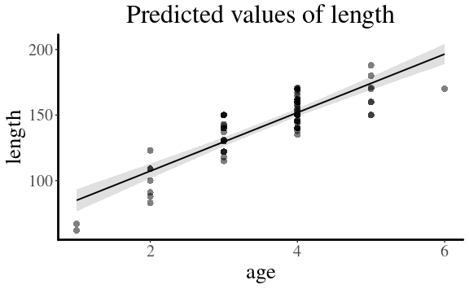

```r
library(sjPlot)
plot_model(bg.mod1, terms="age", type="pred", show.data=TRUE)
```

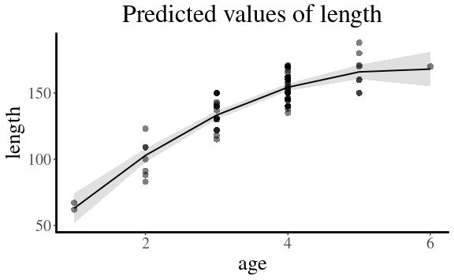

```r
plot_model(bg.mod2, terms="age", type="pred", show.data=TRUE)
```

# Excercise 6C

## LOOCV

For the mammal-sleep dataset, the best entry in our prediction completion discussed in the lecture came from a student who built three models. Model 1 included `LifeSpan` and `Exposure`. Model 2 included `Danger` and `Predation`. Model 3 included just `Exposure`. Fit these three models to the data, then use LOOCV (adapting the code from lecture) to determine which model has the best predictive properties.

```r
mammal.dat <- read.csv(file="../Data/MammalSleep.csv")

library(caret)

sleep.control <- trainControl(method = "LOOCV") #tell the function we want to do leave one out cross validation

mod1.xv <- train(TotalSleep ~ LifeSpan + Exposure, data=mammal.dat, method = "lm", na.action=na.omit, trControl=sleep.control)
mod2.xv <- train(TotalSleep ~ Danger + Predation, data=mammal.dat, method = "lm", na.action=na.omit, trControl= sleep.control)
mod3.xv <- train(TotalSleep ~ Exposure, data=mammal.dat, method = "lm", na.action=na.omit, trControl= sleep.control)

print(mod1.xv$results)
```

|  | intercept | RMSE | Rsquared | MAE |
| --- | --- | --- | --- | --- |
| 1 | TRUE | 3.871428 | 0.3028079 | 3.044557 |

```r
print(mod2.xv$results)
```

|  | intercept | RMSE | Rsquared | MAE |
| --- | --- | --- | --- | --- |
| 1 | TRUE | 3.431105 | 0.4115581 | 2.909208 |

```r
print(mod3.xv$results)
```

|  | intercept | RMSE | Rsquared | MAE |
| --- | --- | --- | --- | --- |
| 1 | TRUE | 3.640241 | 0.3357541 | 2.867349 |

```r
NA
```

### LOOCV shows that model 2 (Danger + Predation) has the best predictive ability.

# Excercise 6D

## Model selection with AIC

```r
model.sel(list(bg.mod1, bg.mod2))
```

```
Model selection table
  (Intrc)   age  age^2 df   logLik  AICc delta weight
2   13.62 54.05 -4.719  4 -295.515 599.6  0.00      1
1   62.65 22.31         3 -306.730 619.8 20.21      0
Models ranked by AICc(x)
```

### Based on the model selection table the model with the quadratic age term was much more strongly supported than the simpler model.

Now use AIC to select from the three models defined in model 6C. Does this agree with the results from LOOCV?

```r
mammal.dat <- read.csv(file="../Data/MammalSleep.csv")
mammal.dat <- mammal.dat[complete.cases(mammal.dat), ]
mod1 <- lm(TotalSleep ~ LifeSpan + Exposure, data=mammal.dat, na.action=na.omit)
mod2 <- lm(TotalSleep ~ Danger + Predation, data=mammal.dat, na.action=na.omit)
mod3 <- lm(TotalSleep ~ Exposure, data=mammal.dat, na.action=na.omit)
library(MuMIn)
model.sel(list(mod1, mod2, mod3), rank="AIC")
```

```
Model selection table
  (Intrc)  Expsr    LfSpn  Dangr Prdtn df  logLik   AIC delta weight
2   15.01                 -5.573 3.566  4 -89.205 186.4  0.00  0.953
3   15.58 -2.066                        3 -93.811 193.6  7.21  0.026
1   15.99 -1.924 -0.04266               4 -93.009 194.0  7.61  0.021
Models ranked by AIC(x)
```

### Based on the above AIC table we see that the Danger and Predation predictors combine to form the best model of sleep. This agrees with the result from the cross-validation selection process.